# Your Digest for Monday, Jan 29, 2024 11:59 PM

> [!INFO] COPD Vs. Asthma pharmacology

> | COPD | Asthma |
> | --- | --- |
> | Ipratropium is mainly used in COPD | Not first line |

[output not shown]

[output not shown]

> [!INFO] Evidence for mortality benefits:

> | Drug | Benefit | Notes |
> | --- | --- | --- |
> | Beta blocker / ACEi | **✓** | First line for HFrEF |
> | MRA (Spi / Eple) | **✓** | Can be added to ACEi, monitor K+ |
> | Vasodialtor | **✓** | Best in african americans |
> | Ivabradine | **✓** | If HR > 70 |
> | ARNI | **✓** | Used if ACEi fails / not tolerated, needs *washout period for switch* |
> | Loop D | symp. | - - - |
> | Digoxin | Lower morbitidy, not mortality | --- |

> [Source](https://www.ncbi.nlm.nih.gov/pmc/articles/PMC5481297/)

> **Beta blockers and ACE inhibitors** have been proven to reduce morbidity and mortality in a wide range of HF_r_EF patients.[7](https://www.ncbi.nlm.nih.gov/pmc/articles/PMC5481297/#b7-ptj4207464),[8](https://www.ncbi.nlm.nih.gov/pmc/articles/PMC5481297/#b8-ptj4207464),[23](https://www.ncbi.nlm.nih.gov/pmc/articles/PMC5481297/#b23-ptj4207464),[25](https://www.ncbi.nlm.nih.gov/pmc/articles/PMC5481297/#b25-ptj4207464) These proven benefits warrant the use of these agents in all patients with HF. **MRAs** such as *spironolactone* and *eplerenone* have also been shown to reduce morbidity and mortality in addition to ACE inhibitors and beta blockers in patients with HF_r_EF, depending on the NYHA class and EF. Therapy should always be individualized, but one of these agents can be added to base therapy for additional benefits.[27](https://www.ncbi.nlm.nih.gov/pmc/articles/PMC5481297/#b27-ptj4207464) Vasodilators show morbidity and mortality benefit in African-American patients in specific situations and can be added to therapy.[45](https://www.ncbi.nlm.nih.gov/pmc/articles/PMC5481297/#b45-ptj4207464),[46](https://www.ncbi.nlm.nih.gov/pmc/articles/PMC5481297/#b46-ptj4207464)

> To help reduce **morbidity** in patients, additional agents may be added for symptomatic relief. In patients with signs and symptoms of fluid overload, diuretics should be used to help mobilize and excrete the excess fluid. Specifically, *loop diuretics* are seen as the first-choice agents, but *thiazides* may be added to overcome loop resistance.[6](https://www.ncbi.nlm.nih.gov/pmc/articles/PMC5481297/#b6-ptj4207464),[42](https://www.ncbi.nlm.nih.gov/pmc/articles/PMC5481297/#b42-ptj4207464) *Digoxin* may be added for symptom relief and to decrease morbidity. Though it does not show mortality reduction, it has demonstrated utility in decreasing hospitalizations for worsening HF_r_EF.[50](https://www.ncbi.nlm.nih.gov/pmc/articles/PMC5481297/#b50-ptj4207464),[51](https://www.ncbi.nlm.nih.gov/pmc/articles/PMC5481297/#b51-ptj4207464)

> **Ivabradine** may be added to treatment in patients on beta blockers who have persistently elevated heart rates or who cannot tolerate beta blockers. The addition of ivabradine will further reduce morbidity, **mortality**, and hospitalizations in these patients, because increased rates of cardiovascular death, hospitalization for HF and myocardial infarction, and coronary revascularization have been reported in patients with heart rates greater than 70 bpm.[52](https://www.ncbi.nlm.nih.gov/pmc/articles/PMC5481297/#b52-ptj4207464),[55](https://www.ncbi.nlm.nih.gov/pmc/articles/PMC5481297/#b55-ptj4207464) Thus, ivabradine should be considered add-on therapy in select patients with persistently elevated heart rates despite beta-blocker therapy.[56](https://www.ncbi.nlm.nih.gov/pmc/articles/PMC5481297/#b56-ptj4207464)

> **ARB and neprilysin inhibitor combination** products (such as sacubitril/valsartan) offer a new option for patients. These agents may have a role in patients who remain symptomatic despite reaching maximum doses of ACE inhibitors/ARBs and beta blockers.

```
    - **sacubitril cannot be used with an ACEI due to an increased risk of angioedema if ACEI and ARNI are used together or dosed in a short timeframe**. When switching between ACEI and sacubitril/valsartan, the patient must undergo a **36-hour washout period** to lower the risk of angioedema. [Source](https://www.ncbi.nlm.nih.gov/books/NBK507904/)
```

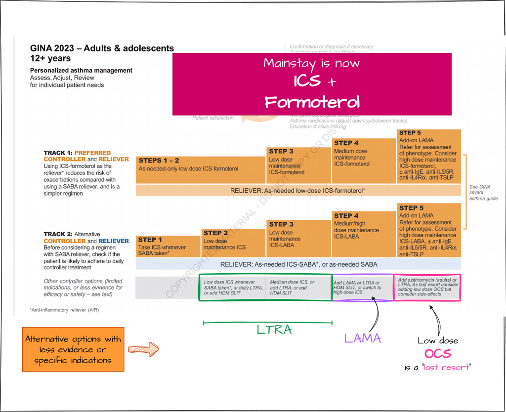

> [!INFO] **Low dose ICS provides most of the benefit**.  
> High dose is needed by very few; side effects cause problems

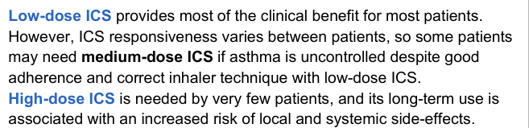